# Random Sampling Plans and Comparisons [A Brief Report[]

Cheng Peng

# 1 Introduction

This will briefly introduce the steps for taking random samples from a finite population. There are two major types of sampling plans: probabilistic and non-probabilistic sampling plans. The probabilistic sampling plans generate statistically valid data based on which one can perform inferential statistical analysis.

In this project, we consider three probabilistic sampling plans: simple random sampling (SRS), stratified sampling, and systematic sampling. We will use the loan default status as a reference variable to assess the performance of the three sampling plans.

The **Bank loan** data set will be treated as a finite population. After we load the data to R, we will perform some data manipulation and exploratory data analysis to identify a stratification variable for stratified sampling.

```r
loan01 = read.csv("https://pengdsci.github.io/datasets/SBAloan/w06-SBAnational01.csv", header = TRUE)[, -1]
loan02 = read.csv("https://pengdsci.github.io/datasets/SBAloan/w06-SBAnational02.csv", header = TRUE)[, -1]
loan03 = read.csv("https://pengdsci.github.io/datasets/SBAloan/w06-SBAnational03.csv", header = TRUE)[, -1]
loan04 = read.csv("https://pengdsci.github.io/datasets/SBAloan/w06-SBAnational04.csv", header = TRUE)[, -1]
loan05 = read.csv("https://pengdsci.github.io/datasets/SBAloan/w06-SBAnational05.csv", header = TRUE)[, -1]
loan06 = read.csv("https://pengdsci.github.io/datasets/SBAloan/w06-SBAnational06.csv", header = TRUE)[, -1]
loan07 = read.csv("https://pengdsci.github.io/datasets/SBAloan/w06-SBAnational07.csv", header = TRUE)[, -1]
loan08 = read.csv("https://pengdsci.github.io/datasets/SBAloan/w06-SBAnational08.csv", header = TRUE)[, -1]
loan09 = read.csv("https://pengdsci.github.io/datasets/SBAloan/w06-SBAnational09.csv", header = TRUE)[, -1]
loan = rbind(loan01, loan02, loan03, loan04, loan05, loan06, loan07, loan08, loan09)
```

# 2 Identifying A Stratification Variable

We use the 2-digit NAICS code as the stratification variable to define the sub-population.

## 2.1 2-Digit NAICS Codes

We will still use NAICS to create a categorical variable that is operational in practice. Recall that in the last note, we summarized the distribution of NAICS in the following table.

```r
naics =as.character(loan$NAICS)  # make a character vector
N=length(naics)                  # find the size of the data.
f.table = -sort(-table(naics))   # sort the vector in descending order
n = length(f.table)              # find the number of distinct industries
n.0 = sum(f.table < 900)         # industry with less than 0.1% of the population size
# A note of length of R variable name: the latest version of R has changed
# the maximum length of variable names from 256 characters to 10,000 characters.
# We should try our best to give meaningful names to R variables.
kable(cbind(Population.size = N, Number.of.Industries=n, Sub.Pop.less.1000 = n.0))
```

| Population.size | Number.of.Industries | Sub.Pop.less.1000 |
| --- | --- | --- |
| 899164 | 1312 | 1140 |

The course web page provides two useful tables. One of the tables https://sta490.s3.amazonaws.com/w03-NAICS-Categories.jpg in the article listed categories based on the first digits of NAICS code. The other related table gives the loan default rate in the corresponding industries https://sta490.s3.amazonaws.com/w03-NAICS-Default-Rates.jpg. You can download these two tables to your local drive and include them in your R Markdown document if you want to practice and reproduce this report.

For the convenience of referring to these tables, I include these two tables in this document.

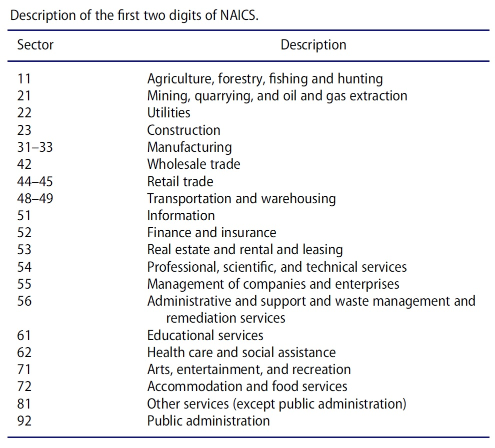

List of all industries using the first two digits of the NAICS code

```r
include_graphics("img/w08-NAICS-Categories.jpg")
```

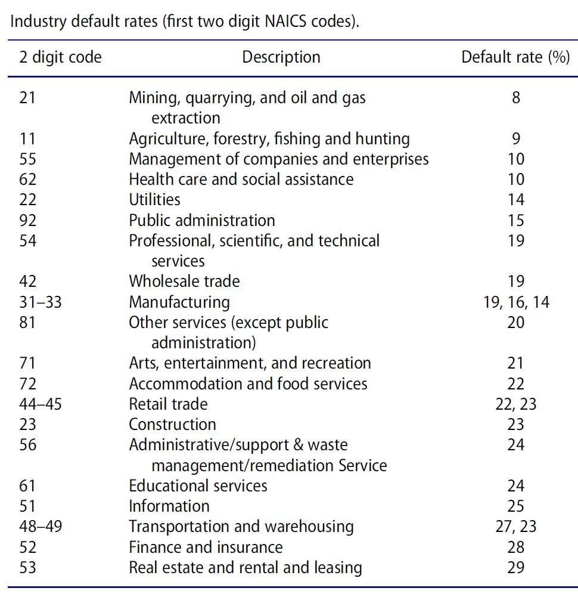

List of all industries using the first two digits of the NAICS code and the corresponding loan default rates

```r
include_graphics("img/w08-NAICS-Default-Rates.jpg")
```

Next, we explore the frequency distribution of the 2-digit NAICS codes and decide the potential combinations of categories with a small size.

```r
NAICS.2.digits = substr(loan$NAICS, 1, 2)   # extract the first two digits of the NAICS code
loan$NAICS2Digit = NAICS.2.digits           # add the above two-digit variable the loan data
freq.table = table(NAICS.2.digits)          # create a regular frequency table
kable(freq.table)                           # convert the regular frequency table to kable
```

| NAICS.2.digits | Freq |
| --- | --- |
| 0 | 201948 |
| 11 | 9005 |
| 21 | 1851 |
| 22 | 663 |
| 23 | 66646 |
| 31 | 11809 |
| 32 | 17936 |
| 33 | 38284 |
| 42 | 48743 |
| 44 | 84737 |
| 45 | 42514 |
| 48 | 20310 |
| 49 | 2221 |
| 51 | 11379 |
| 52 | 9496 |
| 53 | 13632 |
| 54 | 68170 |
| 55 | 257 |
| 56 | 32685 |
| 61 | 6425 |
| 62 | 55366 |
| 71 | 14640 |
| 72 | 67600 |
| 81 | 72618 |
| 92 | 229 |

## 2.2 Combining Categories

We now combine categories suggested in the above NAICS tables in a meaningful way. Before we combine the NAICS codes, we present an example to illustrate how to combine categories using R.

```
cate.vec0=c(1,4,3,6,7,3,6,5,4,6,4,5,8,9,4,3,4,7,3)  # vector of category labels
cate.vec=c(1,4,3,6,7,3,6,5,4,6,4,5,8,9,4,3,4,7,3)   # a copy of the vector of category labels
labs.2.collapse = c(1,6,7)                          # define a vector to store categories {1,6,7}
logic.vec=cate.vec %in% labs.2.collapse             # TRUE/FALSE ==> match not no-match
cate.vec[logic.vec] = 99                            # if matches (i.e., 1, 5, 7), the value
                                                    # will be replaced by 99
matx=rbind(cate.vec0=cate.vec0, cate.vec=cate.vec)  # check the results
colnames(matx) = 1:length(cate.vec)                 # next kable() function requires a column names
kable(matx)
```

We now combine the following sets of 2-digit NAICS codes: (31, 32, 33) will be relabeled as **313**, (48, 49) as **489**, and (44, 45) as **445**. We use strNACIS to denote the resulting stratification variable.

```r
cate.31.33=c("31","32","33")                      # combining categories 31, 32, and 33
cate.48.49 = c("48", "49")
cate.44.45 = c("44", "45")
NAICS2Digit0 = loan$NAICS2Digit                   # extract the 2-digit NAICS
NAICS2Digit =  loan$NAICS2Digit                   # extract the 2-digit NAICS-copy
## combining 31,32, and 33
logic.31.33=NAICS2Digit %in% cate.31.33           # Identify the three categories: 31, 32, 33.
NAICS2Digit[logic.31.33] = 313                      # replace 31, 32, 33 with 313
## combining 44 and 45
logic.44.45=NAICS2Digit %in% cate.44.45           # Identify the three categories: 44 and 45.
NAICS2Digit[logic.44.45] = 445
## combining 48 and 49
logic.48.49=NAICS2Digit %in% cate.48.49           # Identify the three categories: 48 and 49.
NAICS2Digit[logic.48.49] = 489
# check the result
# list(tab.naics0=table(NAICS2Digit0),tab.naics=table(NAICS2Digit))   # check the result
### final step
loan$strNAICS = NAICS2Digit
kable(table(loan$strNAICS))
```

| Var1 | Freq |
| --- | --- |
| 0 | 201948 |
| 11 | 9005 |
| 21 | 1851 |
| 22 | 663 |
| 23 | 66646 |
| 313 | 68029 |
| 42 | 48743 |
| 445 | 127251 |
| 489 | 22531 |
| 51 | 11379 |
| 52 | 9496 |
| 53 | 13632 |
| 54 | 68170 |
| 55 | 257 |
| 56 | 32685 |
| 61 | 6425 |
| 62 | 55366 |
| 71 | 14640 |
| 72 | 67600 |
| 81 | 72618 |
| 92 | 229 |

## 2.3 Loan Default Rates by Industry

We now find the loan default rates by industry defined by the stratification variable strNAICS. The loan default status can be defined by the variable MIS_Status. The following table gives the default rates by industry.

```r
x.table = table(loan$strNAICS, loan$MIS_Status)
no.lab = x.table[,1]      # first column consists of unknown default label
default = x.table[,2]
no.default = x.table[,3]
default.rate = round(100*default/(default+no.default),1)
default.status.rate = cbind(no.lab = no.lab,
                          default = default,
                          no.default = no.default,
                          default.rate=default.rate)
kable(default.status.rate)
```

|  | no.lab | default | no.default | default.rate |
| --- | --- | --- | --- | --- |
| 0 | 281 | 16799 | 184868 | 8.3 |
| 11 | 10 | 812 | 8183 | 9.0 |
| 21 | 0 | 157 | 1694 | 8.5 |
| 22 | 1 | 94 | 568 | 14.2 |
| 23 | 154 | 15463 | 51029 | 23.3 |
| 313 | 126 | 10438 | 57465 | 15.4 |
| 42 | 70 | 9480 | 39193 | 19.5 |
| 445 | 276 | 28868 | 98107 | 22.7 |
| 489 | 123 | 5939 | 16469 | 26.5 |
| 51 | 17 | 2821 | 8541 | 24.8 |
| 52 | 26 | 2692 | 6778 | 28.4 |
| 53 | 44 | 3904 | 9684 | 28.7 |
| 54 | 248 | 12957 | 54965 | 19.1 |
| 55 | 1 | 26 | 230 | 10.2 |
| 56 | 156 | 7661 | 24868 | 23.6 |
| 61 | 24 | 1552 | 4849 | 24.2 |
| 62 | 102 | 5736 | 49528 | 10.4 |
| 71 | 24 | 3013 | 11603 | 20.6 |
| 72 | 89 | 14882 | 52629 | 22.0 |
| 81 | 223 | 14229 | 58166 | 19.7 |
| 92 | 2 | 35 | 192 | 15.4 |

## 2.4 Study Population

```r
del.categories = c("0", "21", "22", "55", "92")       # categories to be deleted in
                                                      # the original population
del.obs.status = !(loan$strNAICS %in% del.categories) # deletion status. ! negation operator
study.pop = loan[del.obs.status,]                     # excluding the categories
kable(t(table(study.pop$strNAICS)))                   # Checking correctness operation
```

| 11 | 23 | 313 | 42 | 445 | 489 | 51 | 52 | 53 | 54 | 56 | 61 | 62 | 71 | 72 | 81 |
| --- | --- | --- | --- | --- | --- | --- | --- | --- | --- | --- | --- | --- | --- | --- | --- |
| 9005 | 66646 | 68029 | 48743 | 127251 | 22531 | 11379 | 9496 | 13632 | 68170 | 32685 | 6425 | 55366 | 14640 | 67600 | 72618 |

So we have defined our study population! The new population size is 694216.

# 3 Sampling Plans

## 3.1 Simple Random Sampling

We define a sampling list and add it to the study population.

```r
study.pop$sampling.frame = 1:length(study.pop$GrAppv)   # sampling list
# names(study.pop)                                      # checking the sampling list variable
sampled.list = sample(1:length(study.pop$GrAppv), 3000) # sampling the list
SRS.sample = study.pop[sampled.list,]                   # extract the sampling units (observations)
## dimension check
dim(SRS.sample )                                        # checking the sample size
```

```
[1] 3000   30
```

## 3.2 Systematic sampling

We can choose a random integer that is less than the jump size (231 in our case) to guarantee to obtain enough samples.

```r
jump.size = dim(study.pop)[1]%/%3000   # find the jump size in the systematic sampling
# jump.size
rand.starting.pt=sample(1:jump.size,1) # find the random starting value
sampling.id = seq(rand.starting.pt, dim(study.pop)[1], jump.size)  # sampling ID
#length(sampling.id)
sys.sample=study.pop[sampling.id,]    # extract the sampling units of systematic samples
dim(sys.sample)
```

```
[1] 3005   30
```

Because the jump size involves rounding error and the population is large, the actual systematic sample size is slightly different from the target size. In this report, I used the integral part of the actual jump size. The actual systematic sampling size is slightly bigger than the target size. We can take away some records from the systematic sample to make the size to be equal to the target size.

## 3.3 Stratified Sampling

We take an SRS from each individual stratum. The sample size should be approximately proportional to the size of the corresponding stratum.

First, we calculate the SRS size for each stratum and then take the SRS from the corresponding stratum. The following table shows the sub-sample sizes.

```r
freq.table = table(study.pop$strNAICS)  # frequency table of strNAICS
rel.freq = freq.table/sum(freq.table)   # relative frequency
strata.size = round(rel.freq*3000)      # strata size allocation
strata.names=names(strata.size)         # extract strNAICS names for accuracy checking
#list(strata.names=names(strata.size),
     #strata.size = strata.size,
     #sample.size = sum(strata.size))
kable(t(strata.size))
```

| 11 | 23 | 313 | 42 | 445 | 489 | 51 | 52 | 53 | 54 | 56 | 61 | 62 | 71 | 72 | 81 |
| --- | --- | --- | --- | --- | --- | --- | --- | --- | --- | --- | --- | --- | --- | --- | --- |
| 39 | 288 | 294 | 211 | 550 | 97 | 49 | 41 | 59 | 295 | 141 | 28 | 239 | 63 | 292 | 314 |

When coding, we use a loop to take simple random samples from each stratum and then combine them to get the stratified sample.

```r
strata.sample = study.pop[1,]    # create a reference data frame
strata.sample$add.id = 1         # add a temporary ID to because in the loop
# i =2                           # testing a single iteration
for (i in 1:length(strata.names)){
   ith.strata.names = strata.names[i]   # extract data frame names
   ith.strata.size = strata.size[i]     # allocated stratum size
   # The following code identifies observations to be selected
   ith.sampling.id = which(study.pop$strNAICS==ith.strata.names)
   ith.strata = study.pop[ith.sampling.id,]  # i-th stratified population
   ith.strata$add.id = 1:dim(ith.strata)[1]  # add sampling list/frame
   # The following code generates a subset of random ID
   ith.sampling.id = sample(1:dim(ith.strata)[1], ith.strata.size)
   ## Create a selection status -- pay attention to the operator: %in%
   ith.sample =ith.strata[ith.strata$add.id %in%ith.sampling.id,]
   ## dim(ith.sample)         $ check the sample
   strata.sample = rbind(strata.sample, ith.sample)  # stack all dataframe!
 }
 # dim(strata.sample)
 strat.sample.final = strata.sample[-1,]     # drop the temporary stratum ID
# kable(head(strat.sample.final[1:5,5]))        # accuracy check! only show the first 5 variables
```

# 4 Performance Analysis of Random Samples

In this section, we perform a comparative analysis of the three random samples. One metric we can use is the default rate in each industry defined by the first two digits of NAICS classification code. That was also used as the stratification variable in the stratified sampling plan.

## 4.1 Population-level Default Rates

We have calculated the default rate across the industries in the previous section. That table includes the category with no NAICS classification code. We will use this population-level industry-specific rate as a reference and compare it with the sample-level industry-specific default rates.

```r
x.table = table(loan$strNAICS, loan$MIS_Status)
no.lab = x.table[,1]   # first column consists of unknown default label
default = x.table[,2]
no.default = x.table[,3]
default.rate = round(100*default/(default+no.default),1)
 default.status.rate = cbind(no.lab = no.lab,
                          default = default,
                          no.default = no.default,
                          default.rate=default.rate)
kable(default.status.rate, caption = "Population size, default counts,
                                      and population default rates")
```

Population size, default counts, and population default rates

|  | no.lab | default | no.default | default.rate |
| --- | --- | --- | --- | --- |
| 0 | 281 | 16799 | 184868 | 8.3 |
| 11 | 10 | 812 | 8183 | 9.0 |
| 21 | 0 | 157 | 1694 | 8.5 |
| 22 | 1 | 94 | 568 | 14.2 |
| 23 | 154 | 15463 | 51029 | 23.3 |
| 313 | 126 | 10438 | 57465 | 15.4 |
| 42 | 70 | 9480 | 39193 | 19.5 |
| 445 | 276 | 28868 | 98107 | 22.7 |
| 489 | 123 | 5939 | 16469 | 26.5 |
| 51 | 17 | 2821 | 8541 | 24.8 |
| 52 | 26 | 2692 | 6778 | 28.4 |
| 53 | 44 | 3904 | 9684 | 28.7 |
| 54 | 248 | 12957 | 54965 | 19.1 |
| 55 | 1 | 26 | 230 | 10.2 |
| 56 | 156 | 7661 | 24868 | 23.6 |
| 61 | 24 | 1552 | 4849 | 24.2 |
| 62 | 102 | 5736 | 49528 | 10.4 |
| 71 | 24 | 3013 | 11603 | 20.6 |
| 72 | 89 | 14882 | 52629 | 22.0 |
| 81 | 223 | 14229 | 58166 | 19.7 |
| 92 | 2 | 35 | 192 | 15.4 |

## 4.2 Industry-Specific Default Rates based on SRS

For comparison, we construct the following table that includes the industry-specific default rates.

```r
 # names(SRS.sample)
x.table = table(SRS.sample$strNAICS, SRS.sample$MIS_Status)
no.lab.srs = x.table[,1]      # first column consists of unknown default label
default.srs = x.table[,2]
no.default.srs = x.table[,3]
default.rate.srs = round(100*default.srs/(default.srs+no.default.srs),1)
##
industry.code = names(default.rate.srs)    # extract NSICS code
industry.name=c("Agri-forest-fish-hunt","Construction",
                "Manufacturing", "Wholesale-trade", "Retail-trade",
                "Transport-warehousing","Information", "Finance-insurance",
                "Real-estate-rental","Prof-sci-tech-ser",
                "Admin-support-waste-mgnt-remed", "Edu-serv",
                "Healthcare-social-assist","Arts-entertain-rec",
                "Accommodation-food-ser", "Other-ser(no-public-admin)")  # actual industry names!
default.rate.pop = default.rate[industry.code]
# cbind(industry.code,industry.name)
SRS.pop.rates = cbind(default.rate.pop,default.rate.srs)
rownames(SRS.pop.rates) = industry.name
kable(SRS.pop.rates, caption="Comparison of industry-specific default rates
                               between population and the SRS.")
```

Comparison of industry-specific default rates between population and the SRS.

|  | default.rate.pop | default.rate.srs |
| --- | --- | --- |
| Agri-forest-fish-hunt | 9.0 | 8.6 |
| Construction | 23.3 | 25.2 |
| Manufacturing | 15.4 | 16.7 |
| Wholesale-trade | 19.5 | 18.2 |
| Retail-trade | 22.7 | 25.9 |
| Transport-warehousing | 26.5 | 24.2 |
| Information | 24.8 | 42.3 |
| Finance-insurance | 28.4 | 14.3 |
| Real-estate-rental | 28.7 | 28.6 |
| Prof-sci-tech-ser | 19.1 | 16.8 |
| Admin-support-waste-mgnt-remed | 23.6 | 20.9 |
| Edu-serv | 24.2 | 38.5 |
| Healthcare-social-assist | 10.4 | 9.8 |
| Arts-entertain-rec | 20.6 | 17.7 |
| Accommodation-food-ser | 22.0 | 22.9 |
| Other-ser(no-public-admin) | 19.7 | 18.0 |

Some of the industry-specific default rates seem to be significantly different. More visual comparisons will be given in the next section.

## 4.3 Industry-specific Rates- Systematics Sample

We will use the sample stratification variable to find the industry-specific rates based on the systematic sample. The following table will include rates of population, SRS, and systematic random samples.

```r
x.table = table(sys.sample$strNAICS, sys.sample$MIS_Status)
no.lab.sys = x.table[,1]      # The first column consists of an unknown default label
default.sys = x.table[,2]
no.default.sys = x.table[,3]
default.rate.sys = round(100*default.sys/(default.sys+no.default.sys),1)
sys.SRS.pop.rates = cbind(default.rate.pop, default.rate.srs, default.rate.sys)
rownames(SRS.pop.rates) = industry.name
kable(sys.SRS.pop.rates, caption="Comparison of industry-specific default rates
                               between population, SRS, and Systematic Sample.")
```

Comparison of industry-specific default rates between population, SRS, and Systematic Sample.

|  | default.rate.pop | default.rate.srs | default.rate.sys |
| --- | --- | --- | --- |
| 11 | 9.0 | 8.6 | 10.5 |
| 23 | 23.3 | 25.2 | 19.9 |
| 313 | 15.4 | 16.7 | 13.6 |
| 42 | 19.5 | 18.2 | 19.5 |
| 445 | 22.7 | 25.9 | 23.3 |
| 489 | 26.5 | 24.2 | 31.6 |
| 51 | 24.8 | 42.3 | 17.2 |
| 52 | 28.4 | 14.3 | 39.3 |
| 53 | 28.7 | 28.6 | 24.6 |
| 54 | 19.1 | 16.8 | 19.7 |
| 56 | 23.6 | 20.9 | 26.1 |
| 61 | 24.2 | 38.5 | 36.4 |
| 62 | 10.4 | 9.8 | 8.6 |
| 71 | 20.6 | 17.7 | 25.5 |
| 72 | 22.0 | 22.9 | 20.2 |
| 81 | 19.7 | 18.0 | 20.6 |

It seems that the systematic sample performs better than the SRS sample.

## 4.4 Industry-specific Default Rates- Stratified Sample

In this section, we put all the information in the following table.

```r
#strat.sample.final
x.table = table(strat.sample.final$strNAICS, strat.sample.final$MIS_Status)
no.lab.str = x.table[,1]      # The first column consists of an unknown default label
default.str = x.table[,2]
no.default.str = x.table[,3]
default.rate.str = round(100*default.str/(default.str+no.default.str),1)
str.SRS.pop.rates = cbind(default.rate.pop, default.rate.srs, default.rate.sys, default.rate.str)
rownames(str.SRS.pop.rates) = industry.name
kable(str.SRS.pop.rates, caption="Comparison of industry-specific default rates
                               between population, SRS, Systematic Sample,
                               and Stratified Samples.")
```

Comparison of industry-specific default rates between population, SRS, Systematic Sample, and Stratified Samples.

|  | default.rate.pop | default.rate.srs | default.rate.sys | default.rate.str |
| --- | --- | --- | --- | --- |
| Agri-forest-fish-hunt | 9.0 | 8.6 | 10.5 | 12.8 |
| Construction | 23.3 | 25.2 | 19.9 | 19.2 |
| Manufacturing | 15.4 | 16.7 | 13.6 | 18.4 |
| Wholesale-trade | 19.5 | 18.2 | 19.5 | 18.5 |
| Retail-trade | 22.7 | 25.9 | 23.3 | 24.0 |
| Transport-warehousing | 26.5 | 24.2 | 31.6 | 34.4 |
| Information | 24.8 | 42.3 | 17.2 | 16.3 |
| Finance-insurance | 28.4 | 14.3 | 39.3 | 17.1 |
| Real-estate-rental | 28.7 | 28.6 | 24.6 | 27.1 |
| Prof-sci-tech-ser | 19.1 | 16.8 | 19.7 | 22.2 |
| Admin-support-waste-mgnt-remed | 23.6 | 20.9 | 26.1 | 22.7 |
| Edu-serv | 24.2 | 38.5 | 36.4 | 21.4 |
| Healthcare-social-assist | 10.4 | 9.8 | 8.6 | 9.2 |
| Arts-entertain-rec | 20.6 | 17.7 | 25.5 | 14.3 |
| Accommodation-food-ser | 22.0 | 22.9 | 20.2 | 22.6 |
| Other-ser(no-public-admin) | 19.7 | 18.0 | 20.6 | 17.8 |

# 5 Visualization - Visual Comparison

In the previous section, we calculated the industry-specific default rates for population, SRS, systematic, and stratified samples. We now create a statistical graphic to compare the default rates among the samples.

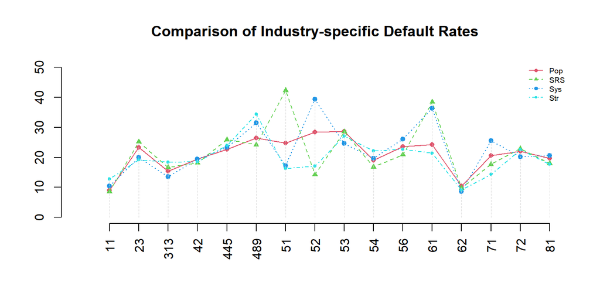

```r
n=length(default.rate.pop)
#par(bg = 'gray')
# empty plot
plot(NULL, xlim=c(0,n), ylim=c(0, 50), xlab="", ylab ="", axes=FALSE)
title("Comparison of Industry-specific Default Rates")
points(1:n, as.vector(default.rate.pop), pch=16, col=2, cex = 0.8)
lines(1:n, as.vector(default.rate.pop), lty=1, col=2, cex = 0.8)
#
points(1:n, as.vector(default.rate.srs), pch=17, col=3, cex = 0.8)
lines(1:n, as.vector(default.rate.srs), lty=2, col=3, cex = 0.8)
#
points(1:n, as.vector(default.rate.sys), pch=19, col=4, cex = 0.8)
lines(1:n, as.vector(default.rate.sys), lty=3, col=4, cex = 0.8)
#
points(1:n, as.vector(default.rate.str), pch=20, col=5, cex = 0.8)
lines(1:n, as.vector(default.rate.str), lty=4, col=5, cex = 0.8)
#
axis(1,at=1:n, label=industry.code, las = 2)
axis(2)
#
rowMax=apply(str.SRS.pop.rates, 1, max) # max default rate in each industry
segments(1:n, rep(0,n), 1:n, rowMax, lty=2, col="lightgray", lwd = 0.5)
legend("topright", c("Pop", "SRS", "Sys", "Str"), lty=1:4, col=2:5, pch=c(16,17,19,20), cex=0.6, bty="n")
```

For ease of interpretation, I make the following table to map the NAICS codes and the corresponding industries.

```r
kable(cbind(industry.name, industry.code),
      caption="Industry NAICS codes and the corresponding names")
```

Industry NAICS codes and the corresponding names

| industry.name | industry.code |
| --- | --- |
| Agri-forest-fish-hunt | 11 |
| Construction | 23 |
| Manufacturing | 313 |
| Wholesale-trade | 42 |
| Retail-trade | 445 |
| Transport-warehousing | 489 |
| Information | 51 |
| Finance-insurance | 52 |
| Real-estate-rental | 53 |
| Prof-sci-tech-ser | 54 |
| Admin-support-waste-mgnt-remed | 56 |
| Edu-serv | 61 |
| Healthcare-social-assist | 62 |
| Arts-entertain-rec | 71 |
| Accommodation-food-ser | 72 |
| Other-ser(no-public-admin) | 81 |

Since the above graph is based on one-time samples, the variation is not included. Therefore, we need more information to do a meaningful comparison. For example, we can package the code in this Markdown document and take, say 1000, samples based on each sampling plan. We then can find the mean industry-specific default rates and the corresponding variation.

## 5.1 Critiques of Visual Representation

Visual representation is a key component in effective storytelling. As an example, we critique the figure of performance comparison of the three sampling plans in the previous section and seek improvements for effective representation.

The following figure is modified based on the comparison line plot given in the previous section.

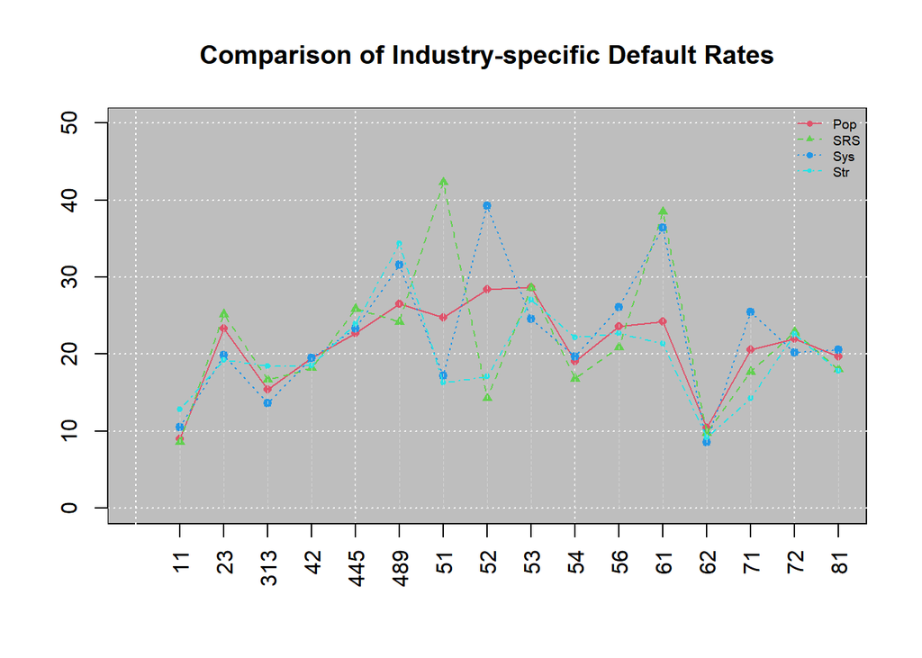

```r
n=length(default.rate.pop)
#par(bg = 'gray')
# empty plot
plot(NULL, xlim=c(0,n), ylim=c(0, 50), xlab="", ylab ="", axes=FALSE)
# Light gray background
rect(par("usr")[1], par("usr")[3],
     par("usr")[2], par("usr")[4],
     col = "gray")

# Add white grid
grid(nx = NULL, ny = NULL,
     col = "white", lwd = 1)

title("Comparison of Industry-specific Default Rates")
points(1:n, as.vector(default.rate.pop), pch=16, col=2, cex = 0.8)
lines(1:n, as.vector(default.rate.pop), lty=1, col=2, cex = 0.8)
#
points(1:n, as.vector(default.rate.srs), pch=17, col=3, cex = 0.8)
lines(1:n, as.vector(default.rate.srs), lty=2, col=3, cex = 0.8)
#
points(1:n, as.vector(default.rate.sys), pch=19, col=4, cex = 0.8)
lines(1:n, as.vector(default.rate.sys), lty=3, col=4, cex = 0.8)
#
points(1:n, as.vector(default.rate.str), pch=20, col=5, cex = 0.8)
lines(1:n, as.vector(default.rate.str), lty=4, col=5, cex = 0.8)
#
axis(1,at=1:n, label=industry.code, las = 2)
axis(2)
#
rowMax=apply(str.SRS.pop.rates, 1, max) # max default rate in each industry
segments(1:n, rep(0,n), 1:n, rowMax, lty=2, col="lightgray", lwd = 0.5)
legend("topright", c("Pop", "SRS", "Sys", "Str"), lty=1:4, col=2:5, pch=c(16,17,19,20), cex=0.6, bty="n")
```

There’s a lot of ink here that doesn’t convey information relevant to the main point we’re trying to make.

- **Grey background**: not only does it provide absolutely no information. it’s also unsightly. After we remove it, we will likely have to darken some of the lines.
- **Grid lines**: it’s very unlikely that our audience cares about the exact values at each data point - it’s the pattern that matters. The grid lines compete with the pattern we’re trying to show.
- **Legend**: It takes time to guess the abbreviation. It also confuses readers.
- **Tick marks**: Why make the reader tilt his or her head to read?
- **Labels of X- and Y- Axis**: labels are missing.
- **Title**: The title should be more specific.
- **Line types**: Use color and line type to differentiate - this will help people who have a color-impaired vision, and also any grey-scale copies of the poster you make (as for handouts).
- **Color coding**: Avoid using use green and red colors in the same graphic to represent different objects. More than 99% of all color-blind people are suffering from a red-green color vision deficiency.

It’s easy to make a graph that looks cleaner and has a higher ratio of information-to-total ink:

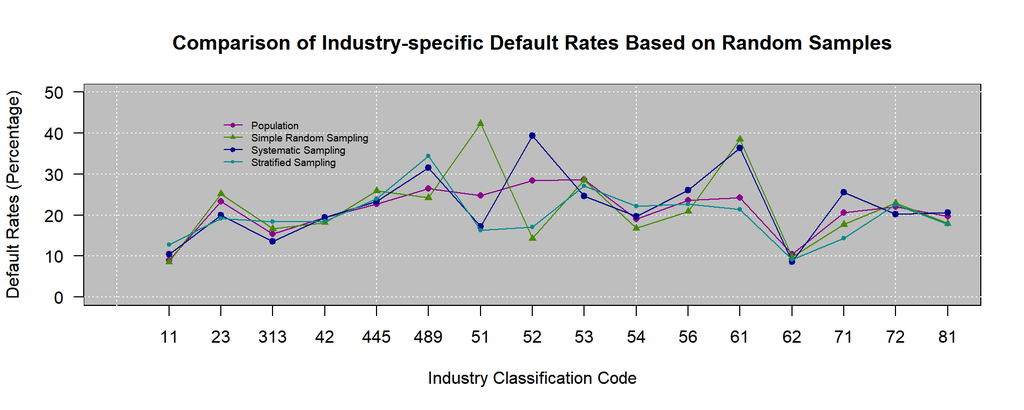

```r
n=length(default.rate.pop)
plot(NULL, xlim=c(0,n), ylim=c(0, 50),
     xlab="Industry Classification Code",
     ylab ="Default Rates (Percentage)", axes=FALSE) # empty plot
# Light gray background
rect(par("usr")[1], par("usr")[3],
     par("usr")[2], par("usr")[4],
     col = "gray")

# Add white grid
grid(nx = NULL, ny = NULL,
     col = "white", lwd = 1)

title("Comparison of Industry-specific Default Rates Based on Random Samples")
points(1:n, as.vector(default.rate.pop), pch=16, col="darkmagenta", cex = 0.8)
lines(1:n, as.vector(default.rate.pop),  lty=1, col="darkmagenta", cex = 0.8)
#
points(1:n, as.vector(default.rate.srs), pch=17, col="chartreuse4", cex = 0.8)
lines(1:n, as.vector(default.rate.srs), lty=1, col="chartreuse4", cex = 0.8)
#
points(1:n, as.vector(default.rate.sys), pch=19, col="darkblue", cex = 0.8)
lines(1:n, as.vector(default.rate.sys), lty=1, col="darkblue", cex = 0.8)
#
points(1:n, as.vector(default.rate.str), pch=20, col="darkcyan", cex = 0.8)
lines(1:n, as.vector(default.rate.str), lty=1, col="darkcyan", cex = 0.8)
#
axis(1,at=1:n, label=industry.code)
axis(2, las = 2)
#
clr = c("darkmagenta","chartreuse4","darkblue","darkcyan")
rowMax=apply(str.SRS.pop.rates, 1, max) # max default rate in each industry
#segments(1:n, rep(0,n), 1:n, rowMax, lty=2, col="lightgray", lwd = 0.5)
legend(2, 45, c("Population", "Simple Random Sampling", "Systematic Sampling", "Stratified Sampling"), lty=rep(1,4), col=clr, pch=c(16,17,19,20), cex=0.6, bty="n")
```

Removing the gray background will make the graph cleaner.

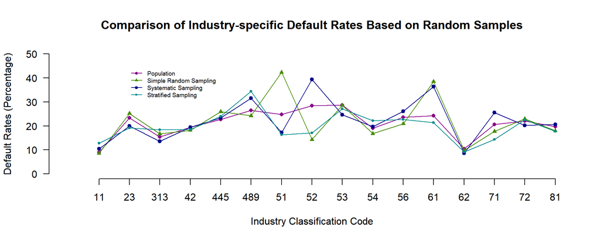

```r
n=length(default.rate.pop)
plot(NULL, xlim=c(0,n), ylim=c(0, 50),
     xlab="Industry Classification Code",
     ylab ="Default Rates (Percentage)", axes=FALSE) # empty plot

title("Comparison of Industry-specific Default Rates Based on Random Samples")
points(1:n, as.vector(default.rate.pop), pch=16, col="darkmagenta", cex = 0.8)
lines(1:n, as.vector(default.rate.pop),  lty=1, col="darkmagenta", cex = 0.8)
#
points(1:n, as.vector(default.rate.srs), pch=17, col="chartreuse4", cex = 0.8)
lines(1:n, as.vector(default.rate.srs), lty=1, col="chartreuse4", cex = 0.8)
#
points(1:n, as.vector(default.rate.sys), pch=19, col="darkblue", cex = 0.8)
lines(1:n, as.vector(default.rate.sys), lty=1, col="darkblue", cex = 0.8)
#
points(1:n, as.vector(default.rate.str), pch=20, col="darkcyan", cex = 0.8)
lines(1:n, as.vector(default.rate.str), lty=1, col="darkcyan", cex = 0.8)
#
axis(1,at=1:n, label=industry.code)
axis(2, las = 2)
#
clr = c("darkmagenta","chartreuse4","darkblue","darkcyan")
rowMax=apply(str.SRS.pop.rates, 1, max) # max default rate in each industry
#segments(1:n, rep(0,n), 1:n, rowMax, lty=2, col="lightgray", lwd = 0.5)
legend(2, 45, c("Population", "Simple Random Sampling", "Systematic Sampling", "Stratified Sampling"), lty=rep(1,4), col=clr, pch=c(16,17,19,20), cex=0.6, bty="n")
```